# Aquaculture area and coastal risk in the Gulf of California

Aquaculture is measured as the area of ponds mapped in each OHI region. In the Gulf of California that class is almost entirely shrimp farms.

The source is the INEGI land-use and vegetation inventory at 1:250,000, as distributed by CONABIO. Each polygon labeled `ACUÍCOLA` is an aquaculture area. The same files are used in the wetland analysis. There the 2021 ponds are cut out of the saltmarsh layer. Here every available year is kept, and the area is summed by region.

The years follow the labels in the CONABIO folder readme: http://www.conabio.gob.mx/informacion/gis/?vns=gis_root/usv/inegi/usv250s7gw.

The 1980–91 file has no `ACUÍCOLA` class, so it is not used. The years that remain are 2001, 2005, 2009, 2013, 2016, and 2021.

The pressure is the recent growth of that pond area, scaled by the coastal area it could affect. Recent growth is the change from 2016 to 2021. The coastal area is the union of three layers: land within 1 km of the shore, the coastal wetland polygons, and the mangrove polygons. Ground that falls in more than one layer is counted once. That ratio is then divided by 0.10. New ponds equal to 10% of the coastal area score 1, and a larger share is held at 1.

```r
library(sf)
library(tidyverse)
library(knitr)

sf_use_s2(FALSE)
```

```
## Spherical geometry (s2) switched off
```

```r
knitr::opts_chunk$set(fig.width = 8, fig.height = 5.5, message = FALSE, warning = FALSE)

data_dir <- "/home/shares/ohi/OHI_GOC/_raw_data/CONABIO_Saltmarsh_landuse_veg"
rgn_path <- "/home/shares/ohi/OHI_GOC/spatial/OHI_regions/goc_ohi_rgns.shp"
coast_path <- "/home/shares/ohi/OHI_GOC/spatial/OHI_regions/goc_coastline.gpkg"
mangrove_path <- "/home/shares/ohi/OHI_GOC/_raw_data/mangrove_Hem/USV_AGRUPADO/USV_AGRUPADO.shp"
out_dir <- "/home/frazier/ohi_goc_prep/_pressures/prs_mariculture/outputs"
shore_m <- 1000
marsh_buffer_m <- 5000
mangrove_buffer_m <- 20000
# New ponds equal to this share of the coastal area score 1.
reference_share <- 0.10
dir.create(out_dir, showWarnings = FALSE, recursive = TRUE)

# File names are the CONABIO series. The year is the label used in this project.
series <- tibble(
  year = c(2001, 2005, 2009, 2013, 2016, 2021),
  file = c(
    "usv250ks2gw/usv250ks2gw.shp",
    "usv250ks3gw/usv250ks3gw.shp",
    "usv250ks4gw/usv250ks4gw.shp",
    "usv250s5ugw/usv250s5ugw.shp",
    "usv250s6gw/usv250s6gw.shp",
    "usv250s7gw/usv250s7gw.shp"
  )
)
```

## 1. OHI regions

Each region has a land polygon and a marine polygon. Shrimp ponds sit on land, often against the shore, so both parts are joined into one polygon per region. A pond that crosses the shoreline is then counted once.

```r
regions_raw <- st_read(rgn_path, quiet = TRUE) %>%
  st_make_valid()

# Land is kept separate so the 1 km strip can be cut to the inland side.
land <- regions_raw %>%
  filter(location == "land")

marine <- regions_raw %>%
  filter(location == "marine") %>%
  st_union() %>%
  st_make_valid()

regions <- regions_raw %>%
  group_by(rgn_id, estado, ecorgn) %>%
  summarise(geometry = st_union(geometry), .groups = "drop") %>%
  st_make_valid() %>%
  arrange(rgn_id) %>%
  mutate(label = paste(rgn_id, estado, sep = "\n"))

regions
```

```
## Simple feature collection with 9 features and 4 fields
## Geometry type: GEOMETRY
## Dimension:     XY
## Bounding box:  xmin: 911292 ymin: 770594.3 xmax: 2550361 ymax: 2349615
## Projected CRS: Mexico ITRF2008 / LCC
## # A tibble: 9 × 5
##   rgn_id   estado              ecorgn                             geometry label
## * <chr>    <chr>               <chr>                        <GEOMETRY [m]> <chr>
## 1 Region_1 Baja_California     Upper_Gulf     MULTIPOLYGON (((1283199 222… "Reg…
## 2 Region_2 Baja_California     Midriff_Region MULTIPOLYGON (((1209736 187… "Reg…
## 3 Region_3 Baja_California_Sur Central_Gulf   MULTIPOLYGON (((1480151 159… "Reg…
## 4 Region_4 Baja_California_Sur Southern_Gulf  MULTIPOLYGON (((1565830 161… "Reg…
## 5 Region_5 Sonora              Upper_Gulf     POLYGON ((1283180 2229154, … "Reg…
## 6 Region_6 Sonora              Midriff_Region MULTIPOLYGON (((1621366 178… "Reg…
## 7 Region_7 Sonora              Central_Gulf   MULTIPOLYGON (((1785727 160… "Reg…
## 8 Region_8 Sinaloa             Southern_Gulf  MULTIPOLYGON (((2119298 116… "Reg…
## 9 Region_9 Nayarit             Southern_Gulf  MULTIPOLYGON (((2176195 839… "Reg…
```

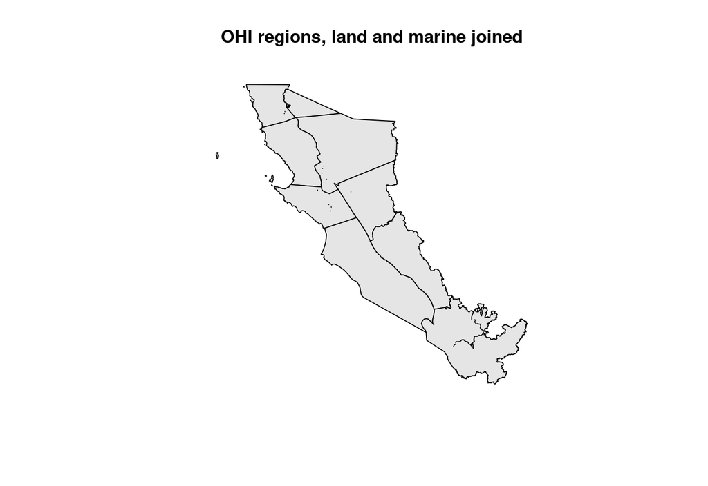

```r
plot(st_geometry(regions), col = "grey90", main = "OHI regions, land and marine joined")
```

## 2. Aquaculture polygons

Each year is read with a filter, so only the `ACUÍCOLA` polygons are loaded. The inventory is in longitude and latitude. It is transformed to the region projection, Mexico ITRF2008 / LCC, before the area is calculated. Area in that projection is square metres, which is stored as square kilometres.

These polygons were drawn at 1:250,000. A small pond can be missing, and the edge of a large pond is approximate. The class is aquaculture, not a species. In this region it is almost all shrimp.

```r
read_ponds <- function(year, file) {
  layer <- tools::file_path_sans_ext(basename(file))
  ponds <- st_read(
    file.path(data_dir, file),
    query = sprintf("SELECT * FROM \"%s\" WHERE DESCRIPCIO = 'ACUÍCOLA'", layer),
    quiet = TRUE
  )
  ponds %>%
    st_make_valid() %>%
    st_transform(st_crs(regions)) %>%
    mutate(year = year) %>%
    select(year)
}

ponds <- map2(series$year, series$file, read_ponds) %>%
  bind_rows()

ponds %>%
  st_drop_geometry() %>%
  count(year, name = "n_polygons")
```

```
##   year n_polygons
## 1 2001          1
## 2 2005        105
## 3 2009        188
## 4 2013        170
## 5 2016        203
## 6 2021        247
```

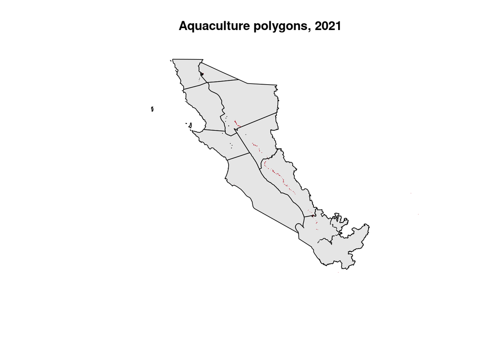

```r
plot(
  st_geometry(regions),
  col = "grey90",
  main = "Aquaculture polygons, 2021"
)
plot(st_geometry(ponds %>% filter(year == 2021)), col = "#b2182b", border = NA, add = TRUE)
```

## 3. Area inside each region

A polygon that crosses a region boundary is split, and each piece is given to the region it falls in. Pieces are then summed. A region with no ponds in a year is recorded as zero, so every region has a row in every year.

```r
pieces <- st_intersection(ponds, regions)
pieces$area_km2 <- as.numeric(st_area(pieces)) / 1e6
pieces <- pieces %>%
  st_drop_geometry() %>%
  group_by(rgn_id, year) %>%
  summarise(area_km2 = sum(area_km2), .groups = "drop")

area <- regions %>%
  st_drop_geometry() %>%
  select(rgn_id, estado, ecorgn, label) %>%
  crossing(year = series$year) %>%
  left_join(pieces, by = c("rgn_id", "year")) %>%
  mutate(area_km2 = replace_na(area_km2, 0)) %>%
  arrange(rgn_id, year)

pond_area <- ponds
pond_area$area_km2 <- as.numeric(st_area(pond_area)) / 1e6
national <- pond_area %>%
  st_drop_geometry() %>%
  group_by(year) %>%
  summarise(national_km2 = sum(area_km2), .groups = "drop")

gulf <- area %>%
  group_by(year) %>%
  summarise(gulf_km2 = sum(area_km2), .groups = "drop") %>%
  left_join(national, by = "year") %>%
  mutate(share_percent = 100 * gulf_km2 / national_km2)

csv_path <- file.path(out_dir, "mariculture_area_km2.csv")
write_csv(area %>% select(rgn_id, year, area_km2), csv_path)

kable(
  area %>% select(rgn_id, estado, ecorgn, year, area_km2),
  digits = 1,
  col.names = c("Region", "State", "Ecoregion", "Year", "Area, km2"),
  caption = "Aquaculture area inside each OHI region"
)
```

Aquaculture area inside each OHI region

| Region | State | Ecoregion | Year | Area, km2 |
| --- | --- | --- | --- | --- |
| Region_1 | Baja_California | Upper_Gulf | 2001 | 0.0 |
| Region_1 | Baja_California | Upper_Gulf | 2005 | 1.5 |
| Region_1 | Baja_California | Upper_Gulf | 2009 | 2.1 |
| Region_1 | Baja_California | Upper_Gulf | 2013 | 2.1 |
| Region_1 | Baja_California | Upper_Gulf | 2016 | 2.1 |
| Region_1 | Baja_California | Upper_Gulf | 2021 | 3.6 |
| Region_2 | Baja_California | Midriff_Region | 2001 | 0.0 |
| Region_2 | Baja_California | Midriff_Region | 2005 | 0.0 |
| Region_2 | Baja_California | Midriff_Region | 2009 | 0.0 |
| Region_2 | Baja_California | Midriff_Region | 2013 | 0.0 |
| Region_2 | Baja_California | Midriff_Region | 2016 | 0.0 |
| Region_2 | Baja_California | Midriff_Region | 2021 | 0.0 |
| Region_3 | Baja_California_Sur | Central_Gulf | 2001 | 0.0 |
| Region_3 | Baja_California_Sur | Central_Gulf | 2005 | 0.0 |
| Region_3 | Baja_California_Sur | Central_Gulf | 2009 | 0.0 |
| Region_3 | Baja_California_Sur | Central_Gulf | 2013 | 0.0 |
| Region_3 | Baja_California_Sur | Central_Gulf | 2016 | 0.0 |
| Region_3 | Baja_California_Sur | Central_Gulf | 2021 | 0.0 |
| Region_4 | Baja_California_Sur | Southern_Gulf | 2001 | 0.0 |
| Region_4 | Baja_California_Sur | Southern_Gulf | 2005 | 0.9 |
| Region_4 | Baja_California_Sur | Southern_Gulf | 2009 | 15.9 |
| Region_4 | Baja_California_Sur | Southern_Gulf | 2013 | 19.5 |
| Region_4 | Baja_California_Sur | Southern_Gulf | 2016 | 19.5 |
| Region_4 | Baja_California_Sur | Southern_Gulf | 2021 | 22.0 |
| Region_5 | Sonora | Upper_Gulf | 2001 | 0.0 |
| Region_5 | Sonora | Upper_Gulf | 2005 | 12.9 |
| Region_5 | Sonora | Upper_Gulf | 2009 | 12.8 |
| Region_5 | Sonora | Upper_Gulf | 2013 | 12.8 |
| Region_5 | Sonora | Upper_Gulf | 2016 | 13.4 |
| Region_5 | Sonora | Upper_Gulf | 2021 | 13.4 |
| Region_6 | Sonora | Midriff_Region | 2001 | 0.0 |
| Region_6 | Sonora | Midriff_Region | 2005 | 34.6 |
| Region_6 | Sonora | Midriff_Region | 2009 | 169.8 |
| Region_6 | Sonora | Midriff_Region | 2013 | 212.9 |
| Region_6 | Sonora | Midriff_Region | 2016 | 220.6 |
| Region_6 | Sonora | Midriff_Region | 2021 | 238.8 |
| Region_7 | Sonora | Central_Gulf | 2001 | 0.0 |
| Region_7 | Sonora | Central_Gulf | 2005 | 157.4 |
| Region_7 | Sonora | Central_Gulf | 2009 | 168.6 |
| Region_7 | Sonora | Central_Gulf | 2013 | 219.1 |
| Region_7 | Sonora | Central_Gulf | 2016 | 240.9 |
| Region_7 | Sonora | Central_Gulf | 2021 | 243.4 |
| Region_8 | Sinaloa | Southern_Gulf | 2001 | 0.0 |
| Region_8 | Sinaloa | Southern_Gulf | 2005 | 438.6 |
| Region_8 | Sinaloa | Southern_Gulf | 2009 | 486.3 |
| Region_8 | Sinaloa | Southern_Gulf | 2013 | 529.8 |
| Region_8 | Sinaloa | Southern_Gulf | 2016 | 601.8 |
| Region_8 | Sinaloa | Southern_Gulf | 2021 | 684.5 |
| Region_9 | Nayarit | Southern_Gulf | 2001 | 0.0 |
| Region_9 | Nayarit | Southern_Gulf | 2005 | 24.6 |
| Region_9 | Nayarit | Southern_Gulf | 2009 | 51.8 |
| Region_9 | Nayarit | Southern_Gulf | 2013 | 50.3 |
| Region_9 | Nayarit | Southern_Gulf | 2016 | 50.3 |
| Region_9 | Nayarit | Southern_Gulf | 2021 | 101.0 |

```r
kable(
  gulf,
  digits = 1,
  col.names = c("Year", "Inside the nine regions, km2", "Whole CONABIO file, km2", "Percent inside the regions"),
  caption = "How much of the national aquaculture layer falls inside the Gulf regions"
)
```

How much of the national aquaculture layer falls inside the Gulf regions

| Year | Inside the nine regions, km2 | Whole CONABIO file, km2 | Percent inside the regions |
| --- | --- | --- | --- |
| 2001 | 0.0 | 1.2 | 0.0 |
| 2005 | 670.6 | 677.7 | 99.0 |
| 2009 | 907.3 | 917.4 | 98.9 |
| 2013 | 1046.6 | 1061.2 | 98.6 |
| 2016 | 1148.7 | 1172.4 | 98.0 |
| 2021 | 1306.7 | 1338.3 | 97.6 |

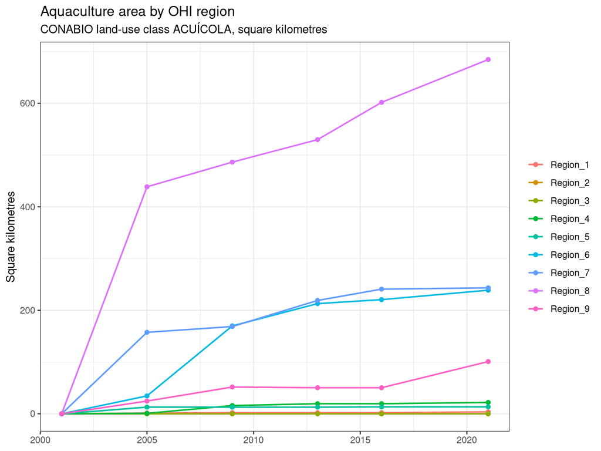

```r
ggplot(area, aes(year, area_km2, color = rgn_id)) +
  geom_line(linewidth = 0.7) +
  geom_point(size = 1.6) +
  labs(
    title = "Aquaculture area by OHI region",
    subtitle = "CONABIO land-use class ACUÍCOLA, square kilometres",
    x = NULL,
    y = "Square kilometres",
    color = NULL
  ) +
  theme_bw()
```

The table is /home/frazier/ohi_goc_prep/_pressures/prs_mariculture/outputs/mariculture_area_km2.csv.

## 4. Coastal area used to scale the pressure

The denominator is the area where new shrimp ponds are treated as a risk to the coast. It has three parts.

The first part is every piece of land within 1 km of the Gulf shoreline. The shoreline is the same line used for the direct-human pressure. The buffer is cut to the land side of the OHI regions, so open water is left out. This strip includes shore that has no mapped wetland.

The second part is the 2021 coastal wetland layer from the habitat analysis. That layer keeps three CONABIO classes, and only where they fall within 5 km of the marine region:

- `VEGETACIÓN HALÓFILA HIDRÓFILA` and its secondary shrub class, the tidal saltmarsh
- `VEGETACIÓN DE DUNAS COSTERAS`, the coastal dunes
- `VEGETACIÓN HALÓFILA XERÓFILA` and its secondary shrub class, the dry salt scrub

The 5 km limit is what keeps inland salt flats out of the saltmarsh layer. The distance is measured from the marine region, which follows the lagoons, rather than from the outer beach alone.

The third part is mangrove. The classes are `MANGLAR` and the secondary mangrove classes in the Hem land-cover layer. They are clipped to 20 km of the marine region, which is the same window used for the mangrove habitat score. Inside these regions that window keeps the mapped forest, including the lagoon mangrove set back from the outer beach.

The three parts are merged, and the area of the merged polygon is measured inside each region. A shore cell that is also mangrove is counted once.

```r
# Lines and points can appear where a polygon only touches a boundary.
as_polygons <- function(x) {
  x <- st_collection_extract(st_make_valid(x), "POLYGON")
  x[!st_is_empty(x), ]
}

# A ring around the marine region, joined back to the marine region.
marine_plus <- function(distance_m) {
  outer <- st_buffer(marine, distance_m)
  ring <- st_difference(outer, marine) %>%
    st_make_valid()
  st_union(marine, ring) %>%
    st_make_valid()
}

coast <- st_read(coast_path, quiet = TRUE) %>%
  st_transform(st_crs(regions)) %>%
  st_union() %>%
  st_make_valid()

shore_band <- st_buffer(coast, shore_m) %>%
  st_make_valid()

inland_1km <- land %>%
  st_intersection(shore_band) %>%
  as_polygons()

wetland_classes <- c(
  "VEGETACIÓN HALÓFILA HIDRÓFILA",
  "VEGETACIÓN SECUNDARIA ARBUSTIVA DE VEGETACIÓN HALÓFILA HIDRÓFILA",
  "VEGETACIÓN DE DUNAS COSTERAS",
  "VEGETACIÓN HALÓFILA XERÓFILA",
  "VEGETACIÓN SECUNDARIA ARBUSTIVA DE VEGETACIÓN HALÓFILA XERÓFILA"
)

quoted_classes <- paste0("'", wetland_classes, "'", collapse = ", ")
marsh <- st_read(
  file.path(data_dir, "usv250s7gw/usv250s7gw.shp"),
  query = sprintf(
    "SELECT * FROM \"usv250s7gw\" WHERE DESCRIPCIO IN (%s)",
    quoted_classes
  ),
  quiet = TRUE
) %>%
  st_transform(st_crs(regions)) %>%
  st_make_valid() %>%
  st_crop(st_bbox(regions)) %>%
  st_intersection(marine_plus(marsh_buffer_m)) %>%
  as_polygons()

mangrove_classes <- c(
  "MANGLAR",
  "VEGETACIÓN SECUNDARIA ARBÓREA DE MANGLAR",
  "VEGETACIÓN SECUNDARIA ARBUSTIVA DE MANGLAR",
  "VEGETACIÓN SECUNDARIA HERBÁCEA DE MANGLAR"
)

mangrove <- st_read(mangrove_path, quiet = TRUE) %>%
  filter(DESCRIP_AG %in% mangrove_classes) %>%
  st_transform(st_crs(regions)) %>%
  st_make_valid() %>%
  st_intersection(marine_plus(mangrove_buffer_m)) %>%
  as_polygons()

risk <- st_sf(
  geometry = st_union(c(
    st_geometry(inland_1km),
    st_geometry(marsh),
    st_geometry(mangrove)
  )) %>%
    st_make_valid()
)

area_in_regions <- function(layer) {
  pieces <- st_intersection(st_make_valid(layer), regions) %>%
    as_polygons()
  pieces$area_km2 <- as.numeric(st_area(pieces)) / 1e6
  pieces %>%
    st_drop_geometry() %>%
    group_by(rgn_id) %>%
    summarise(area_km2 = sum(area_km2), .groups = "drop")
}

risk_parts <- regions %>%
  st_drop_geometry() %>%
  select(rgn_id, estado, ecorgn) %>%
  left_join(area_in_regions(inland_1km) %>% rename(shore_km2 = area_km2), by = "rgn_id") %>%
  left_join(area_in_regions(marsh) %>% rename(marsh_km2 = area_km2), by = "rgn_id") %>%
  left_join(area_in_regions(mangrove) %>% rename(mangrove_km2 = area_km2), by = "rgn_id") %>%
  left_join(area_in_regions(risk) %>% rename(risk_km2 = area_km2), by = "rgn_id") %>%
  mutate(across(ends_with("_km2"), ~ replace_na(.x, 0))) %>%
  arrange(rgn_id)

kable(
  risk_parts,
  digits = 1,
  col.names = c(
    "Region", "State", "Ecoregion",
    "1 km inland, km2", "Coastal wetland, km2", "Mangrove, km2", "Merged, km2"
  ),
  caption = "Parts of the coastal risk area. The merged column counts overlap once."
)
```

Parts of the coastal risk area. The merged column counts overlap once.

| Region | State | Ecoregion | 1 km inland, km2 | Coastal wetland, km2 | Mangrove, km2 | Merged, km2 |
| --- | --- | --- | --- | --- | --- | --- |
| Region_1 | Baja_California | Upper_Gulf | 100.0 | 8.2 | 0.0 | 105.5 |
| Region_2 | Baja_California | Midriff_Region | 665.3 | 133.1 | 0.0 | 749.0 |
| Region_3 | Baja_California_Sur | Central_Gulf | 366.0 | 75.6 | 0.0 | 408.6 |
| Region_4 | Baja_California_Sur | Southern_Gulf | 882.2 | 45.4 | 6.3 | 896.8 |
| Region_5 | Sonora | Upper_Gulf | 159.2 | 210.6 | 0.0 | 314.0 |
| Region_6 | Sonora | Midriff_Region | 645.5 | 570.7 | 32.7 | 984.0 |
| Region_7 | Sonora | Central_Gulf | 512.8 | 854.6 | 119.2 | 1211.9 |
| Region_8 | Sinaloa | Southern_Gulf | 1145.6 | 521.2 | 1002.5 | 2300.0 |
| Region_9 | Nayarit | Southern_Gulf | 370.6 | 57.2 | 973.9 | 1346.7 |

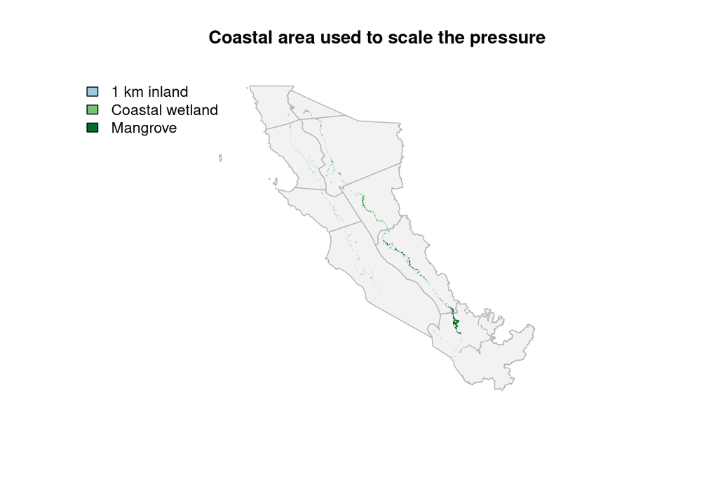

```r
plot(
  st_geometry(regions),
  col = "grey95",
  border = "grey70",
  main = "Coastal area used to scale the pressure"
)
plot(st_geometry(inland_1km), col = "#9ecae1", border = NA, add = TRUE)
plot(st_geometry(marsh), col = "#74c476", border = NA, add = TRUE)
plot(st_geometry(mangrove), col = "#006d2c", border = NA, add = TRUE)
legend(
  "topleft",
  legend = c("1 km inland", "Coastal wetland", "Mangrove"),
  fill = c("#9ecae1", "#74c476", "#006d2c"),
  bty = "n"
)
```

Blue is the 1 km inland strip. Green is the coastal wetland. Dark green is mangrove. Where those layers overlap, the later colour is drawn on top. The area in the table is the union, so the drawing does not change the number.

## 5. Pressure from recent pond growth

Pond area in 2021 minus pond area in 2016 is the growth. Dividing by the merged coastal area puts that growth on a common scale. A region with a large mangrove coast can add many square kilometres of ponds and still receive a smaller score than a region with a short shore.

Ponds on dry scrub, outside the wetland and mangrove polygons, remain in the numerator. The share is five years of new ponds divided by the coastal area. Dividing that share by 0.10 puts it on a 0 to 1 scale: new ponds equal to 10% of the coastal area score 1, and a larger share is held at 1. A difference smaller than 0.001 km² is stored as zero. That is what remains when an unchanged pond is intersected with the regions in two separate years.

```r
score <- area %>%
  filter(year %in% c(2016, 2021)) %>%
  select(rgn_id, estado, ecorgn, year, area_km2) %>%
  pivot_wider(names_from = year, values_from = area_km2, names_prefix = "pond_") %>%
  left_join(risk_parts %>% select(rgn_id, risk_km2), by = "rgn_id") %>%
  mutate(
    change_km2 = pond_2021 - pond_2016,
    # Separate intersections of an unchanged pond leave a trace well below 0.001 km2.
    change_km2 = if_else(abs(change_km2) < 0.001, 0, change_km2),
    share = change_km2 / risk_km2,
    pressure = pmin(share / reference_share, 1),
    year = 2021
  ) %>%
  arrange(rgn_id)

risk_path <- file.path(out_dir, "mariculture_risk.csv")
pressure_path <- file.path(out_dir, "mariculture_pressure.csv")

write_csv(
  score %>%
    select(rgn_id, estado, ecorgn, pond_2016, pond_2021, change_km2, risk_km2, share, pressure),
  risk_path
)
write_csv(
  score %>% select(rgn_id, year, pressure),
  pressure_path
)

kable(
  score %>%
    select(rgn_id, estado, ecorgn, pond_2016, pond_2021, change_km2, risk_km2, share, pressure),
  digits = 3,
  col.names = c(
    "Region", "State", "Ecoregion",
    "2016 ponds, km2", "2021 ponds, km2", "Change, km2",
    "Coastal area, km2", "Share of coast", "Pressure"
  ),
  caption = "Pressure = share of coastal area / 0.10, held at 1. A share of 0.10 scores 1."
)
```

Pressure = share of coastal area / 0.10, held at 1. A share of 0.10 scores 1.

| Region | State | Ecoregion | 2016 ponds, km2 | 2021 ponds, km2 | Change, km2 | Coastal area, km2 | Share of coast | Pressure |
| --- | --- | --- | --- | --- | --- | --- | --- | --- |
| Region_1 | Baja_California | Upper_Gulf | 2.136 | 3.620 | 1.484 | 105.496 | 0.014 | 0.141 |
| Region_2 | Baja_California | Midriff_Region | 0.000 | 0.000 | 0.000 | 748.971 | 0.000 | 0.000 |
| Region_3 | Baja_California_Sur | Central_Gulf | 0.000 | 0.000 | 0.000 | 408.597 | 0.000 | 0.000 |
| Region_4 | Baja_California_Sur | Southern_Gulf | 19.524 | 21.969 | 2.445 | 896.805 | 0.003 | 0.027 |
| Region_5 | Sonora | Upper_Gulf | 13.403 | 13.403 | 0.000 | 313.973 | 0.000 | 0.000 |
| Region_6 | Sonora | Midriff_Region | 220.615 | 238.849 | 18.234 | 984.024 | 0.019 | 0.185 |
| Region_7 | Sonora | Central_Gulf | 240.871 | 243.375 | 2.505 | 1211.939 | 0.002 | 0.021 |
| Region_8 | Sinaloa | Southern_Gulf | 601.768 | 684.507 | 82.740 | 2300.019 | 0.036 | 0.360 |
| Region_9 | Nayarit | Southern_Gulf | 50.343 | 100.957 | 50.614 | 1346.677 | 0.038 | 0.376 |

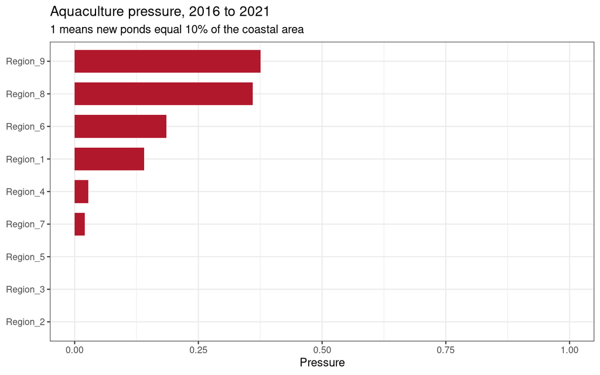

```r
ggplot(score, aes(reorder(rgn_id, pressure), pressure)) +
  geom_col(fill = "#b2182b", width = 0.7) +
  coord_flip() +
  scale_y_continuous(limits = c(0, 1)) +
  labs(
    title = "Aquaculture pressure, 2016 to 2021",
    subtitle = "1 means new ponds equal 10% of the coastal area",
    x = NULL,
    y = "Pressure"
  ) +
  theme_bw()
```

The full table is /home/frazier/ohi_goc_prep/_pressures/prs_mariculture/outputs/mariculture_risk.csv. The pressure file used with the other pressure layers is /home/frazier/ohi_goc_prep/_pressures/prs_mariculture/outputs/mariculture_pressure.csv, with one row per region and the year set to 2021.